# SI 618 Day 11: Classification

Version 2021.04.04.1.CT

Today we're going to focus on classification and model evaluation.

```python
import seaborn as sns
import pandas as pd
```

```python
data = sns.load_dataset('iris')
data.groupby('species').mean()
```

| species | sepal_length | sepal_width | petal_length | petal_width |
| --- | --- | --- | --- | --- |
| setosa | 5.006 | 3.428 | 1.462 | 0.246 |
| versicolor | 5.936 | 2.770 | 4.260 | 1.326 |
| virginica | 6.588 | 2.974 | 5.552 | 2.026 |

```python
from sklearn.model_selection import train_test_split
# "target" contains the column name of the classification labels
target = "species"

X = data.drop(target,axis=1)
y = data[target]

seed = 7
test_size = 0.33
X_train, X_test, y_train, y_test = train_test_split(X, y, test_size=test_size, random_state=seed)
```

```python
from sklearn.metrics import accuracy_score
from sklearn.metrics import classification_report, confusion_matrix
```

## Naive Bayes

```python
from sklearn.naive_bayes import GaussianNB

model = GaussianNB()
model.fit(X_train, y_train)
# make predictions for test data
y_pred = model.predict(X_test)
predictions = y_pred
```

$accuracy = \frac{True Positives + True Negatives}{All Samples}$

$precision = \frac{True Positives}{True Positives + False Positives}$

$recall = \frac{True Positives}{True Positives + False Negatives}$

$F1 = \frac{2 \times (Precision \times Recall)}{Precision + Recall}$

```python
# evaluate predictions
accuracy = accuracy_score(y_test, predictions)
print("Accuracy: %.2f%%" % (accuracy * 100.0))

from sklearn.metrics import classification_report, confusion_matrix
print(confusion_matrix(y_test, y_pred))
print(classification_report(y_test, y_pred))
```

```
Accuracy: 90.00%
[[14  0  0]
 [ 0 15  3]
 [ 0  2 16]]
              precision    recall  f1-score   support

      setosa       1.00      1.00      1.00        14
  versicolor       0.88      0.83      0.86        18
   virginica       0.84      0.89      0.86        18

    accuracy                           0.90        50
   macro avg       0.91      0.91      0.91        50
weighted avg       0.90      0.90      0.90        50
```

## Logistic Regression

```python
from sklearn.linear_model import LogisticRegression
model = LogisticRegression(solver='liblinear',multi_class="auto")
model.fit(X_train, y_train)
y_pred = model.predict(X_test)

print(accuracy_score(y_test, y_pred))
print(confusion_matrix(y_test, y_pred))
print(classification_report(y_test, y_pred))
```

```
0.9
[[14  0  0]
 [ 0 14  4]
 [ 0  1 17]]
              precision    recall  f1-score   support

      setosa       1.00      1.00      1.00        14
  versicolor       0.93      0.78      0.85        18
   virginica       0.81      0.94      0.87        18

    accuracy                           0.90        50
   macro avg       0.91      0.91      0.91        50
weighted avg       0.91      0.90      0.90        50
```

## Support Vector Machines

```python
from sklearn import svm
model = svm.SVC(gamma="scale",kernel="rbf")
model.fit(X_train, y_train)
y_pred = model.predict(X_test)

print(accuracy_score(y_test, y_pred))
print(confusion_matrix(y_test, y_pred))
print(classification_report(y_test, y_pred))
```

```
0.9
[[14  0  0]
 [ 0 17  1]
 [ 0  4 14]]
              precision    recall  f1-score   support

      setosa       1.00      1.00      1.00        14
  versicolor       0.81      0.94      0.87        18
   virginica       0.93      0.78      0.85        18

    accuracy                           0.90        50
   macro avg       0.91      0.91      0.91        50
weighted avg       0.91      0.90      0.90        50
```

## Decision Trees

```python
from sklearn.tree import DecisionTreeClassifier
from sklearn.model_selection import train_test_split
from sklearn.metrics import accuracy_score
from IPython.display import Image
```

```python
model = DecisionTreeClassifier(
    random_state=3,
    criterion='entropy',
    splitter='best',
    max_depth=5,
    min_samples_split=2)

model.fit(X_train,y_train)

y_pred = model.predict(X_test)

# evaluate predictions
accuracy = model.score(X_test, y_test)
print("Accuracy: %.2f%%" % (accuracy * 100.0))
```

```
Accuracy: 92.00%
```

```python
import matplotlib.pyplot as plt
from sklearn.tree import plot_tree
```

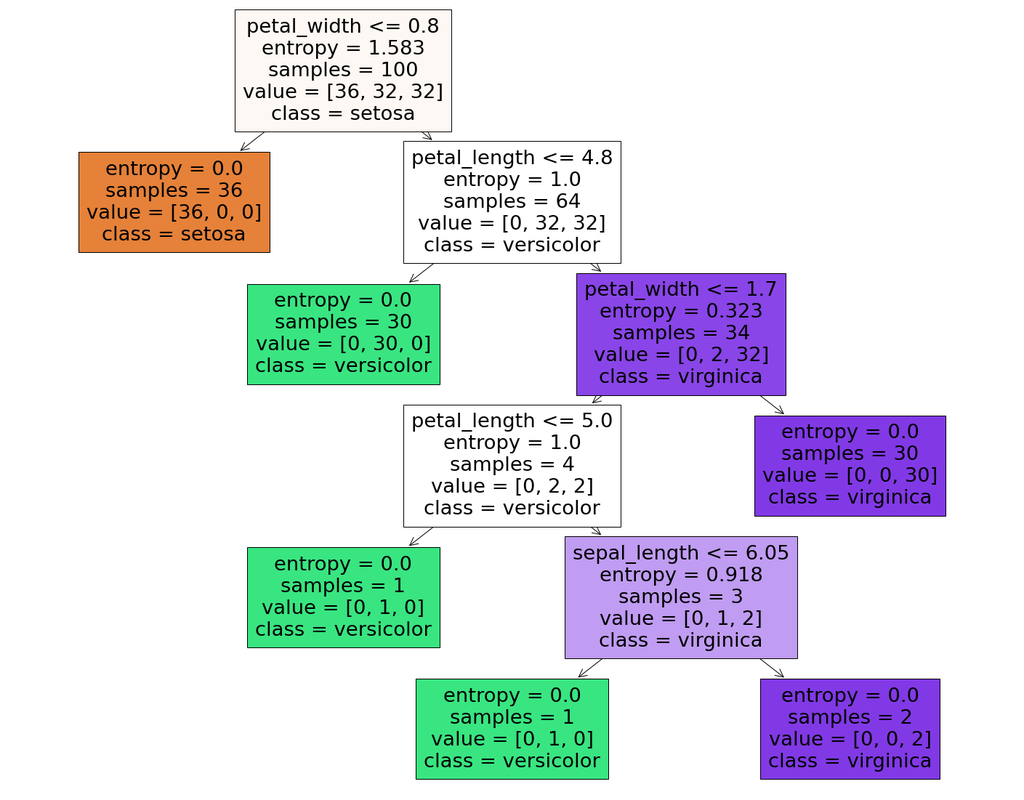

```python
# based on https://mljar.com/blog/visualize-decision-tree/
fig = plt.figure(figsize=(25,20))
# we use '_' to capture the return from plot_tree(...) and never do anything with it
_ = plot_tree(model,
                   feature_names=X.columns,  # ordered list of features
                   class_names=y.unique(), # unique() is handy here due to numerical sorting of classes
                   filled=True)
```

```python
from sklearn.metrics import accuracy_score
accuracy = accuracy_score(y_test, y_pred)
print(accuracy)

from sklearn.metrics import classification_report, confusion_matrix
print(confusion_matrix(y_test, y_pred))
print(classification_report(y_test, y_pred))
```

```
0.92
[[14  0  0]
 [ 0 16  2]
 [ 0  2 16]]
              precision    recall  f1-score   support

      setosa       1.00      1.00      1.00        14
  versicolor       0.89      0.89      0.89        18
   virginica       0.89      0.89      0.89        18

    accuracy                           0.92        50
   macro avg       0.93      0.93      0.93        50
weighted avg       0.92      0.92      0.92        50
```

## Random Forests

```python
seed = 42

from sklearn.ensemble import RandomForestClassifier
from sklearn.model_selection import train_test_split
from sklearn.metrics import accuracy_score

model = RandomForestClassifier(
    n_estimators=100,
    random_state=seed,
    criterion='entropy',
    max_depth=None,
    min_samples_split=2)

model.fit(X_train,y_train)

y_pred = model.predict(X_test)

# evaluate predictions
accuracy = model.score(X_test, y_test)
print("Accuracy: %.2f%%" % (accuracy * 100.0))
```

```
Accuracy: 92.00%
```

```python
from sklearn.metrics import classification_report, confusion_matrix
print(confusion_matrix(y_test, y_pred))
print(classification_report(y_test, y_pred))
```

```
[[14  0  0]
 [ 0 16  2]
 [ 0  2 16]]
              precision    recall  f1-score   support

      setosa       1.00      1.00      1.00        14
  versicolor       0.89      0.89      0.89        18
   virginica       0.89      0.89      0.89        18

    accuracy                           0.92        50
   macro avg       0.93      0.93      0.93        50
weighted avg       0.92      0.92      0.92        50
```

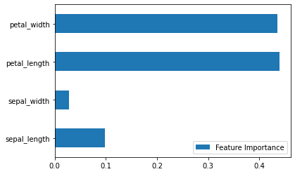

```python
# Check feature importance
feat_importance = model.feature_importances_
pd.DataFrame({'Feature Importance':feat_importance},
            index=list(X)).plot(kind='barh')
```

## Cross-validation

### Tuning the model

The model paramters are called *hyperparameters*. Setting them to appropriate values and running the model experiment again can be tedious, so we have a technique called cross-validation to help with this.

From http://scikit-learn.org/stable/modules/cross_validation.html:

> When evaluating different settings (“hyperparameters”) for estimators, such as the C setting that must be manually set for an SVM, there is still a risk of overfitting on the test set because the parameters can be tweaked until the estimator performs optimally. This way, knowledge about the test set can “leak” into the model and evaluation metrics no longer report on generalization performance. To solve this problem, yet another part of the dataset can be held out as a so-called “validation set”: training proceeds on the training set, after which evaluation is done on the validation set, and when the experiment seems to be successful, final evaluation can be done on the test set.

> However, by partitioning the available data into three sets, we drastically reduce the number of samples which can be used for learning the model, and the results can depend on a particular random choice for the pair of (train, validation) sets.

> A solution to this problem is a procedure called cross-validation (CV for short). A test set should still be held out for final evaluation, but the validation set is no longer needed when doing CV. In the basic approach, called k-fold CV, the training set is split into k smaller sets (other approaches are described below, but generally follow the same principles). The following procedure is followed for each of the k “folds”:

> A model is trained using of the folds as training data; the resulting model is validated on the remaining part of the data (i.e., it is used as a test set to compute a performance measure such as accuracy). The performance measure reported by k-fold cross-validation is then the average of the values computed in the loop. This approach can be computationally expensive, but does not waste too much data (as is the case when fixing an arbitrary validation set), which is a major advantage in problems such as inverse inference where the number of samples is very small.

The mean score and the 95% confidence interval (2 x the standard deviation) of the score estimate are hence given by:

```python
from sklearn.model_selection import cross_val_score
scores = cross_val_score(model,X,y, cv=5, n_jobs=-1)
print("Accuracy: %0.2f%% (+/- %0.2f)" % (scores.mean()*100, scores.std() * 2*100))
```

```
Accuracy: 96.00% (+/- 4.99)
```

But let's say we want to fiddle with the hyperparameters.

To do this, we first set up a parameter grid with the lists of paramters we want to try:

```python
param_grid = {
                 'n_estimators': [5, 10, 15, 20, 25, 30, 35, 40, 50],
                 'max_depth': [2, 5, 7, 9],
             }
```

We now run the cross-validation on the classifier. Note: this will take a while (why?).

```python
from sklearn.model_selection import GridSearchCV

grid_clf = GridSearchCV(model, param_grid, cv=10, n_jobs=-1)
grid_clf.fit(X,y)
```

```
GridSearchCV(cv=10,
             estimator=RandomForestClassifier(criterion='entropy',
                                              random_state=42),
             n_jobs=-1,
             param_grid={'max_depth': [2, 5, 7, 9],
                         'n_estimators': [5, 10, 15, 20, 25, 30, 35, 40, 50]})
```

```python
grid_clf.best_estimator_
```

```
RandomForestClassifier(criterion='entropy', max_depth=5, n_estimators=40,
                       random_state=42)
```

```python
grid_clf.best_params_
```

```
{'max_depth': 5, 'n_estimators': 40}
```

```python
# Details, which can be imported into a pandas dataframe:
results = pd.DataFrame(grid_clf.cv_results_)
results.head()
```

|  | mean_fit_time | std_fit_time | mean_score_time | std_score_time | param_max_depth | param_n_estimators | params | split0_test_score | split1_test_score | split2_test_score | split3_test_score | split4_test_score | split5_test_score | split6_test_score | split7_test_score | split8_test_score | split9_test_score | mean_test_score | std_test_score | rank_test_score |
| --- | --- | --- | --- | --- | --- | --- | --- | --- | --- | --- | --- | --- | --- | --- | --- | --- | --- | --- | --- | --- |
| 0 | 0.039170 | 0.015195 | 0.009400 | 0.004568 | 2 | 5 | {'max_depth': 2, 'n_estimators': 5} | 1.000000 | 0.933333 | 1.0 | 0.933333 | 0.933333 | 0.866667 | 0.866667 | 1.0 | 1.0 | 1.0 | 0.953333 | 0.052068 | 16 |
| 1 | 0.061093 | 0.021326 | 0.006846 | 0.002386 | 2 | 10 | {'max_depth': 2, 'n_estimators': 10} | 1.000000 | 0.933333 | 1.0 | 0.933333 | 0.933333 | 0.866667 | 0.866667 | 1.0 | 1.0 | 1.0 | 0.953333 | 0.052068 | 16 |
| 2 | 0.058148 | 0.008574 | 0.009229 | 0.002751 | 2 | 15 | {'max_depth': 2, 'n_estimators': 15} | 0.933333 | 0.933333 | 1.0 | 0.933333 | 0.933333 | 0.933333 | 0.866667 | 1.0 | 1.0 | 1.0 | 0.953333 | 0.042687 | 16 |
| 3 | 0.079338 | 0.012488 | 0.008606 | 0.001575 | 2 | 20 | {'max_depth': 2, 'n_estimators': 20} | 0.933333 | 0.933333 | 1.0 | 0.933333 | 0.933333 | 0.933333 | 0.866667 | 1.0 | 1.0 | 1.0 | 0.953333 | 0.042687 | 16 |
| 4 | 0.079197 | 0.003994 | 0.008913 | 0.001242 | 2 | 25 | {'max_depth': 2, 'n_estimators': 25} | 0.933333 | 0.933333 | 1.0 | 0.933333 | 0.933333 | 0.933333 | 0.866667 | 1.0 | 1.0 | 1.0 | 0.953333 | 0.042687 | 16 |

```python
# Use the tuned hyperparameters
model = grid_clf.best_estimator_
from sklearn.model_selection import cross_val_score
scores = cross_val_score(model,X,y, cv=10)
print("Accuracy: %0.2f%% (+/- %0.2f)" % (scores.mean()*100, scores.std() * 2*100))
```

```
Accuracy: 96.67% (+/- 6.67)
```

## Task

Recall the `penguins` dataset from earlier in the coourse. Choosing from Naive Bayes, Logistic Regression, Support Vector Machines, Decision Trees and Random Forests, find the "best" classifier to classify penguin species. Note that you can set up your code to run one classifier, and then change only the classified specification and keep the rest of the code the same.

```python
penguins = sns.load_dataset('penguins')
penguins.dropna(inplace=True)
```

```python
penguins.species.unique()
```

```
array(['Adelie', 'Chinstrap', 'Gentoo'], dtype=object)
```

```python
penguins['species'].value_counts()
```

```
Adelie       146
Gentoo       119
Chinstrap     68
Name: species, dtype: int64
```

```python
from sklearn.model_selection import StratifiedShuffleSplit

sss = StratifiedShuffleSplit(n_splits=1, test_size=0.2, random_state=42)
for train_index, test_index in sss.split(penguins, penguins['species']):
    penguins_train_set = penguins.loc[penguins.index.intersection(train_index)]
    penguins_test_set = penguins.loc[penguins.index.intersection(test_index)]
```

```python
penguins_train_set.shape,penguins_test_set.shape
```

```
((257, 7), (67, 7))
```

```python
penguins_train_X = penguins_train_set.drop('species',axis=1)
penguins_train_y = penguins_train_set['species'].copy()
penguins_test_X = penguins_test_set.drop('species',axis=1)
penguins_test_y = penguins_test_set[['species']].copy()
```

```python
import numpy as np
from sklearn.compose import ColumnTransformer
from sklearn.preprocessing import StandardScaler
from sklearn.preprocessing import OneHotEncoder

num_attribs = list(penguins_train_X.select_dtypes(include=[np.number]))
cat_attribs = list(penguins_train_X.select_dtypes(exclude=[np.number]))

full_pipeline = ColumnTransformer([
    ("num", StandardScaler(), num_attribs),
    ("cat", OneHotEncoder(), cat_attribs),
])

penguins_train_X_prepared = full_pipeline.fit_transform(penguins_train_X)
penguins_test_X_prepared = full_pipeline.transform(penguins_test_X)
```

```python
import numpy as np
import matplotlib.pyplot as plt
from matplotlib.colors import ListedColormap
from sklearn.model_selection import train_test_split
from sklearn.preprocessing import StandardScaler
#from sklearn.datasets import make_moons, make_circles, make_classification
from sklearn.neural_network import MLPClassifier
from sklearn.neighbors import KNeighborsClassifier
from sklearn.svm import SVC
from sklearn.gaussian_process import GaussianProcessClassifier
from sklearn.gaussian_process.kernels import RBF
from sklearn.tree import DecisionTreeClassifier
from sklearn.ensemble import RandomForestClassifier, AdaBoostClassifier
from sklearn.naive_bayes import GaussianNB
from sklearn.discriminant_analysis import QuadraticDiscriminantAnalysis
```

```python
# from https://scikit-learn.org/stable/auto_examples/classification/plot_classifier_comparison.html
names = ["Nearest Neighbors", "Linear SVM", "RBF SVM", "Gaussian Process",
         "Decision Tree", "Random Forest", "Neural Net", "AdaBoost",
         "Naive Bayes"]

classifiers = [
    KNeighborsClassifier(3),
    SVC(kernel="linear", C=0.025),
    SVC(gamma=2, C=1),
    GaussianProcessClassifier(1.0 * RBF(1.0)),
    DecisionTreeClassifier(max_depth=5),
    RandomForestClassifier(max_depth=5, n_estimators=10, max_features=1),
    MLPClassifier(alpha=1, max_iter=1000),
    AdaBoostClassifier(),
    GaussianNB(),
]
```

```python
X_train = penguins_train_X_prepared
y_train = penguins_train_y
X_test = penguins_test_X_prepared
y_test = penguins_test_y

for name, clf in zip(names, classifiers):
    clf.fit(X_train, y_train)
    y_pred = clf.predict(X_test)

    # evaluate predictions
    accuracy = clf.score(X_test, y_test)
    print("%s Accuracy: %.2f%%" % (name,accuracy * 100.0))
```

```
Nearest Neighbors Accuracy: 97.01%
Linear SVM Accuracy: 95.52%
RBF SVM Accuracy: 94.03%
Gaussian Process Accuracy: 98.51%
Decision Tree Accuracy: 94.03%
Random Forest Accuracy: 95.52%
Neural Net Accuracy: 98.51%
AdaBoost Accuracy: 79.10%
Naive Bayes Accuracy: 70.15%
```

Let's define a classifier that always classifies a species as "not Chinstrap":

```python
from sklearn.base import BaseEstimator

class NeverChinstrapClassifier(BaseEstimator):
    def fit(self, X, y=None):
        return self
    def predict(self, X):
        return np.zeros((len(X), 1), dtype=bool)
```

```python
y_train_chinstrap = penguins_train_y == 'Chinstrap'
```

```python
y_train_chinstrap.sum()
```

```
53
```

```python
from sklearn.model_selection import cross_val_score
never_chinstrap_clf = NeverChinstrapClassifier()
cvs = cross_val_score(never_chinstrap_clf,penguins_train_X_prepared,y_train_chinstrap,cv=5,scoring='accuracy')
cvs
```

```
array([1.        , 1.        , 0.23529412, 0.7254902 , 1.        ])
```

```python
np.mean(cvs)
```

```
0.7921568627450981
```

Let's take a look at some additional ways to assess how good a model (classifier) is:

```python
from sklearn.tree import DecisionTreeClassifier
from sklearn.model_selection import train_test_split
from sklearn.metrics import accuracy_score
```

```python
from sklearn.ensemble import RandomForestClassifier
from sklearn.model_selection import cross_val_predict
forest_clf = RandomForestClassifier(n_estimators=100,max_depth=3,random_state=42)

y_probas_forest = cross_val_predict(forest_clf, penguins_train_X_prepared, y_train_chinstrap, cv=3,
                                    method="predict_proba")
```

```python
hasattr(forest_clf, "decision_function")
```

```
False
```

```python
hasattr(forest_clf, "predict_proba")
```

```
True
```

```python
y_train_pred = cross_val_predict(forest_clf, penguins_train_X_prepared, y_train_chinstrap, cv=3)
```

```python
confusion_matrix(y_train_pred,y_train_chinstrap)
```

```
array([[203,   3],
       [  1,  50]])
```

```python
y_probas_forest
```

```
array([[9.62015881e-01, 3.79841185e-02],
       [9.55855841e-01, 4.41441586e-02],
       [9.57848582e-01, 4.21514181e-02],
       [9.47780014e-01, 5.22199860e-02],
       [9.35622119e-01, 6.43778807e-02],
       [9.67874303e-01, 3.21256966e-02],
       [9.59991491e-01, 4.00085090e-02],
       [9.65261496e-01, 3.47385045e-02],
       [9.62770267e-01, 3.72297325e-02],
       [9.53939491e-01, 4.60605090e-02],
       [8.97921922e-01, 1.02078078e-01],
       [9.63903772e-01, 3.60962283e-02],
       [7.72334677e-01, 2.27665323e-01],
       [9.56394146e-01, 4.36058536e-02],
       [9.75461835e-01, 2.45381653e-02],
       [9.84701754e-01, 1.52982456e-02],
       [9.56394146e-01, 4.36058536e-02],
       [9.56394146e-01, 4.36058536e-02],
       [9.58647020e-01, 4.13529801e-02],
       [9.61980353e-01, 3.80196467e-02],
       [9.65647020e-01, 3.43529801e-02],
       [8.29765599e-01, 1.70234401e-01],
       [8.26341722e-01, 1.73658278e-01],
       [7.42385107e-01, 2.57614893e-01],
       [7.83423252e-01, 2.16576748e-01],
       [6.99345310e-01, 3.00654690e-01],
       [7.37890483e-01, 2.62109517e-01],
       [7.21953016e-01, 2.78046984e-01],
       [7.60612588e-01, 2.39387412e-01],
       [7.84734759e-01, 2.15265241e-01],
       [7.79260366e-01, 2.20739634e-01],
       [7.98924346e-01, 2.01075654e-01],
       [3.85259092e-01, 6.14740908e-01],
       [8.45383757e-01, 1.54616243e-01],
       [7.60612588e-01, 2.39387412e-01],
       [7.20548664e-01, 2.79451336e-01],
       [5.34719993e-01, 4.65280007e-01],
       [9.49481866e-01, 5.05181343e-02],
       [9.78932734e-01, 2.10672658e-02],
       [9.55858853e-01, 4.41411475e-02],
```

[output cut: 202 more lines]

```
       [9.34806287e-01, 6.51937135e-02],
       [9.83423503e-01, 1.65764973e-02],
       [9.75945689e-01, 2.40543112e-02],
       [9.66501244e-01, 3.34987556e-02],
       [9.25361842e-01, 7.46381579e-02],
       [9.75945689e-01, 2.40543112e-02],
       [9.92709217e-01, 7.29078305e-03],
       [9.92709217e-01, 7.29078305e-03],
       [9.97927036e-01, 2.07296357e-03],
       [9.15625000e-01, 8.43750000e-02],
       [9.87739636e-01, 1.22603639e-02],
       [9.92709217e-01, 7.29078305e-03],
       [9.21181287e-01, 7.88187135e-02],
       [9.92709217e-01, 7.29078305e-03],
       [9.87739636e-01, 1.22603639e-02]])
```

```python
from sklearn.metrics import roc_curve
y_scores_forest = y_probas_forest[:, 1]   # score = proba of positive class
fpr_forest, tpr_forest, thresholds_forest = roc_curve(y_train_chinstrap,y_scores_forest)#,pos_label='Male')
```

```python
from sklearn.metrics import precision_recall_curve

precisions, recalls, thresholds = precision_recall_curve(y_train_chinstrap,y_scores_forest)
```

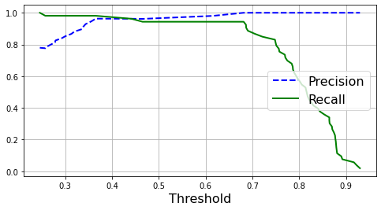

```python
def plot_precision_recall_vs_threshold(precisions, recalls, thresholds):
    plt.plot(thresholds, precisions[:-1], "b--", label="Precision", linewidth=2)
    plt.plot(thresholds, recalls[:-1], "g-", label="Recall", linewidth=2)
    plt.legend(loc="center right", fontsize=16) # Not shown in the book
    plt.xlabel("Threshold", fontsize=16)        # Not shown
    plt.grid(True)                              # Not shown
#    plt.axis([0, 3, 0, 1])
#recall_90_precision = recalls[np.argmax(precisions >= 0.90)]
#threshold_90_precision = thresholds[np.argmax(precisions >= 0.90)]

plt.figure(figsize=(8, 4))                                                                  # Not shown
plot_precision_recall_vs_threshold(precisions, recalls, thresholds)
plt.show()
```

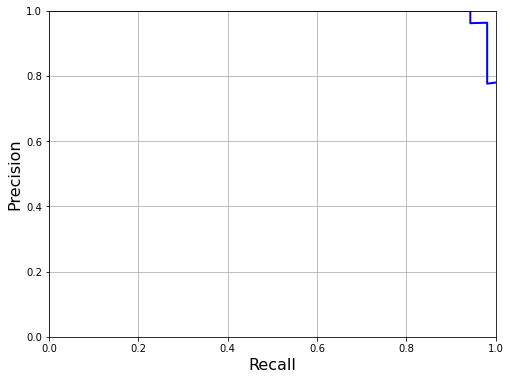

```python
def plot_precision_vs_recall(precisions, recalls):
    plt.plot(recalls, precisions, "b-", linewidth=2)
    plt.xlabel("Recall", fontsize=16)
    plt.ylabel("Precision", fontsize=16)
    plt.axis([0, 1, 0, 1])
    plt.grid(True)

plt.figure(figsize=(8, 6))
plot_precision_vs_recall(precisions, recalls)
```

```python
threshold_90_precision = thresholds[np.argmax(precisions >= 0.90)]
```

```python
threshold_90_precision
```

```
0.33882086671724276
```

```python
y_train_pred_90 = (y_scores_forest >= threshold_90_precision)
```

```python
from sklearn.metrics import precision_score, recall_score
print(precision_score(y_train_chinstrap, y_train_pred_90))
print(recall_score(y_train_chinstrap, y_train_pred_90))
```

```
0.9122807017543859
0.9811320754716981
```

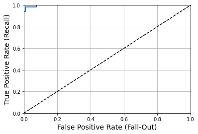

```python
def plot_roc_curve(fpr, tpr, label=None):
    plt.plot(fpr, tpr, linewidth=2, label=label)
    plt.plot([0, 1], [0, 1], 'k--') # dashed diagonal
    plt.axis([0, 1, 0, 1])                                    # Not shown in the book
    plt.xlabel('False Positive Rate (Fall-Out)', fontsize=14) # Not shown
    plt.ylabel('True Positive Rate (Recall)', fontsize=14)    # Not shown
    plt.grid(True)                                            # Not shown

plot_roc_curve(fpr_forest, tpr_forest)
plt.show()
```

```python
from sklearn.metrics import roc_auc_score
roc_auc_score(y_train_chinstrap, y_scores_forest)
```

```
0.9982426933037366
```